# VS Code + AI Agents

4 Steps to AI-Assisted Research

Van Bavel Lab | Research Assistant Workshop

2026-04-21

## Four Steps to Get Started

1. **GitHub Pro for free** — apply via GitHub for Education
2. **Download VS Code** — current versions include AI chat features
3. **Open your folder** — give Copilot context about your project
4. **Use the recommended prompt** — folder context + question + R workflow + slides

# Step 1: GitHub Pro for Free

## Apply via GitHub for Education

**NYU students may be eligible for GitHub Pro and Copilot-related benefits at no cost through GitHub for Education.**

**Tip**

Sign up at **education.github.com** using your **@nyu.edu** email.

**How to apply:**

1. Go to education.github.com → click *“Get student benefits”*
2. Sign in with (or create) a GitHub account using your **@nyu.edu** email
3. Verify student status — usually instant with a `.edu` address
4. Review the benefits currently available on your GitHub account and activate the AI features tied to your plan

**What to expect:**

- **GitHub Copilot access** tied to your GitHub account plan
- Private repositories with advanced features
- GitHub Actions minutes and other developer tools

**Note**

GitHub’s student and Copilot plan details can change. Check the current eligibility, limits, and included benefits on GitHub’s site when you sign up.

# Step 2: Download VS Code

## Install VS Code and Turn On AI Features

### 1. Download VS Code

- Go to **code.visualstudio.com**
- Download for Windows, Mac, or Linux
- Free and open-source

### 2. Sign In to Use AI Features

- Open VS Code
- In current versions, chat and inline AI features are built in
- Click the Copilot icon or Accounts menu and choose **Use AI Features** / sign in with GitHub
- Open the Chat panel: `Ctrl+Alt+I` (Win) · `Cmd+Option+I` (Mac)
- If you’re on an older VS Code version, you may still need the GitHub Copilot extension

**Note**

**Naming check:** as of April 2026, the official VS Code docs still call the product **GitHub Copilot in VS Code**. **Agents** and **agentic workflows** are features inside that system, not a full rename of the product.

```
┌────────────────────────────────────────────────┐
│  VS Code                                       │
│                                                │
│  ┌──────┐  ┌─────────────────┐  ┌───────────┐  │
│  │      │  │                 │  │   CHAT    │  │
│  │ File │  │  Code Editor    │  │   PANEL   │  │
│  │ Tree │  │                 │  │           │  │
│  │      │  │ library(tidy-   │  │ You: ...  │  │
│  │      │  │   verse)        │  │           │  │
│  │      │  │ df |> group_by  │  │ Copilot:  │  │
│  │      │  │   (...)         │  │ ...       │  │
│  └──────┘  └─────────────────┘  └───────────┘  │
│                                                │
│  ──────────── Terminal ──────────────────────  │
└────────────────────────────────────────────────┘
```

# Step 3: Open Your Folder

## Give Copilot Context About Your Project

**File → Open Folder** and select your project directory.

**Why this matters:**

When you open a folder, Copilot can see your files. Drag files into the Chat panel — or type `#filename` — so Copilot understands your specific data, variable names, and existing code.

**Good things to have in your folder:**

- Your data file (`.csv`, `.rds`, etc.)
- Any existing R scripts
- A Quarto document (`.qmd`) if you have one

**Referencing files in Chat:**

`#codebase`  
`#spreadsheet.xlsx`  
Take a look at the relevant files in this folder, especially the spreadsheet containing the data.

Copilot reads those files and writes code tailored to your exact columns, data structure, and existing scripts — no copy-pasting required.

**Note**

The more context Copilot has, the more specific and accurate its answers will be.

# Step 4: The Recommended Prompt

## A Better Default Prompt

Use this structure for any research question:

Take a look at the relevant files in this folder, especially the spreadsheet containing the data and any existing analysis scripts.

[Your question]

Communicate the results with rendered Quarto slides. If possible, write R scripts and generate publication-quality figures for any relevant analyses.

## Why This Prompt Works

**Each part has a job:**

| Part | What it produces |
| --- | --- |
| Folder context | Uses your real files instead of toy examples |
| Question | Focused, relevant answer |
| R workflow | Reproducible, runnable analysis |
| Figures | Visual summary of the evidence |
| Quarto slides | A shareable, self-documenting report |

You go from a question to a **presentation-ready report** — all in one prompt.

**The complete pipeline:**

**Files + context**  
↓  
**Question**  
↓  
**R Script** → **Figures**  
↓  
**Quarto Slides**  
↓  
**Shareable HTML / PDF presentation**

## Example Prompt

*“Take a look at the relevant files in this folder, especially the spreadsheet containing the data and any existing analysis scripts.*

*Figure out the main empirical pattern in these data and tell me what I should report.*

*Communicate the results with rendered Quarto slides. If possible, write R scripts and generate publication-quality figures for any relevant analyses.”*

**What the agent can produce:** an R script, cleaner data-processing steps, modern figures, and a `.qmd` file you can render into a polished HTML presentation.

## Prompt Variants by Use Case

- Experimental Data
- Meta-Analysis
- Complex Problems
- Brainstorming

> “Take a look at the relevant files in this folder, especially the spreadsheet containing the data. Identify the main experimental contrasts, run the appropriate analysis in R, generate figures that show the full pattern in the data, and summarize the findings in rendered Quarto slides.”

> “Look through the spreadsheet and related files in this folder. Clean the meta-analytic dataset in R, calculate the key effect-size summaries, generate figures such as a forest plot or another informative visual if appropriate, and present the findings, assumptions, and caveats in rendered Quarto slides.”

> “Look through the relevant files in this folder and figure out why the current analysis or report is failing, inconsistent, or confusing. Fix the problem, explain what changed, and render updated Quarto slides or outputs if that helps communicate the solution.”

> “Look through the notes, data, and draft materials in this folder. Propose several plausible interpretations, follow-up analyses, or study ideas, rank them by usefulness, and package the options into concise Quarto slides so I can review and discuss them later.”

## Example Output: Figure from the R Script

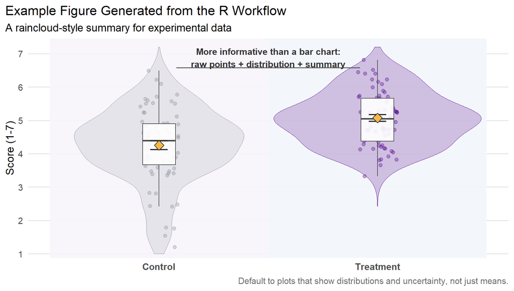

Figure 1

## You’re Ready

1. ✅ **GitHub Pro** — free via GitHub for Education
2. ✅ **VS Code AI features** — turned on and signed in
3. ✅ **Folder open** — Copilot has context about your project
4. ✅ **Recommended prompt** — folder context → question → R workflow → slides

**Tip**

**Start right now:** open your project folder, drag your data file into Chat, and try the four-part prompt with a real question from your research.